# Sex

# 1 Description of DataSchema variable

The description of harmonised variable is the following:

- Short name: `sex`
- Variable label: `Biological sex`
- Variable description: `Participant's biological sex`
- Domain: `Socio-demographic and economic characteristics`
- Value type: `categorical`
- Category coding:

| **Code** | **Category Label** |
| --- | --- |
| 0 | Female |
| 1 | Male |

- Category missings:

| **Code** | **Category Label** |
| --- | --- |
| 991 | CAPI/interviewer error |
| 992 | Impute |
| 993 | Disable to measure |
| 994 | Not attempt/not done |
| 995 | Does not answer |
| 996 | Not applicable |
| 997 | Refuse |
| 998 | Do not know |
| 999 | Missing |

# 2 Data process

## 2.1 England

### 2.1.1 Wave 1

#### 2.1.1.1 Study-specific variable description

| **Name** | `indsex` |
| --- | --- |
| **Label** | `Definitive sex variable` |
| **Table name** | `wave_1_core_data_v3` |
| **Categories** | `1 = Male` `2 = Female` |
| **Description** |  |

Biological sex

| Sample size | Missing values |
| --- | --- |
| 12099 | 0 |

Category

|  | 1 | 2 |
| --- | --- | --- |
| Frequency | 5335.00 | 6764.00 |
| Percentage | 44.09 | 55.91 |

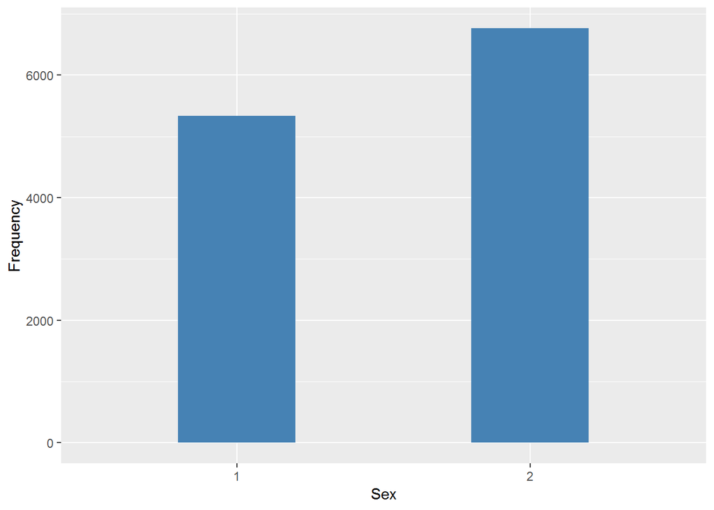

#### 2.1.1.2 Harmonisation algorithm

To compute the harmonized variable from the study-specific variable it has to be recoded as follows:

- `1 "Male" into 1`
- `2 "Female" into 0`
- `NA into 999`

**R script:**

```r
ELSA_ds_w1 <- tibble(id = ELSA_w1_sex$id)
ELSA_ds_w1$sex <- car::recode(ELSA_w1_sex$indsex, "1=1; 2=0")
ELSA_ds_w1$sex <- labelled(ELSA_ds_w1$sex, labels = c(Female = 0, Male = 1,
    Missing = 999, `Do not know` = 998, Refuse = 997, `Not attempt not done` = 994,
    `Does not answer` = 995, `Not applicable` = 996, `Disable to measure` = 993,
    Impute = 992, `CAPI interviewer error` = 991))
label(ELSA_ds_w1$sex) <- ds_label
```

#### 2.1.1.3 Statistical description of the new harmonised variable

Biological sex

| Sample size | Missing values |
| --- | --- |
| 12099 | 0 |

Category

|  | 0 | 1 |
| --- | --- | --- |
| Frequency | 6764.00 | 5335.00 |
| Percentage | 55.91 | 44.09 |

Type of missing

|  | 991 | 992 | 993 | 994 | 995 | 996 | 997 | 998 | 999 | NA |
| --- | --- | --- | --- | --- | --- | --- | --- | --- | --- | --- |
| Frequency | 0 | 0 | 0 | 0 | 0 | 0 | 0 | 0 | 0 | 0 |
| Percentage | 0 | 0 | 0 | 0 | 0 | 0 | 0 | 0 | 0 | 0 |

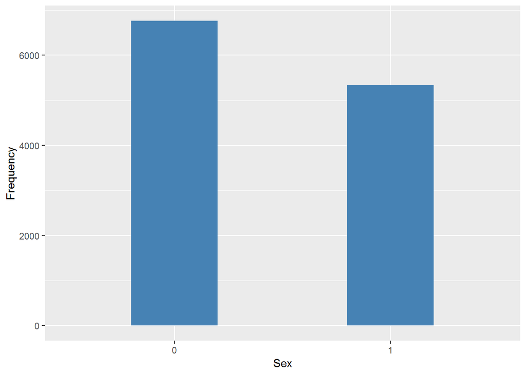

#### 2.1.1.4 Validation

|  | 2->0 | 1 |
| --- | --- | --- |
| BeforeH | 6764 | 5335 |
| AfterH | 6764 | 5335 |

### 2.1.2 Wave 2

#### 2.1.2.1 Study-specific variable description

| **Name** | `indsex` |
| --- | --- |
| **Label** | `Definitive sex variable. Priority: Disex, Dhsex` |
| **Table name** | `wave_2_core_data_v4` |
| **Categories** | `1 = Male` `2 = Female` |
| **Missings** | `-9 = Refusal` `-8 = Don't Know` `-1 = Not applicable` |
| **Description** |  |

Biological sex

| Sample size | Missing values |
| --- | --- |
| 9432 | 0 |

Category

|  | 1 | 2 |
| --- | --- | --- |
| Frequency | 4125.00 | 5307.00 |
| Percentage | 43.73 | 56.27 |

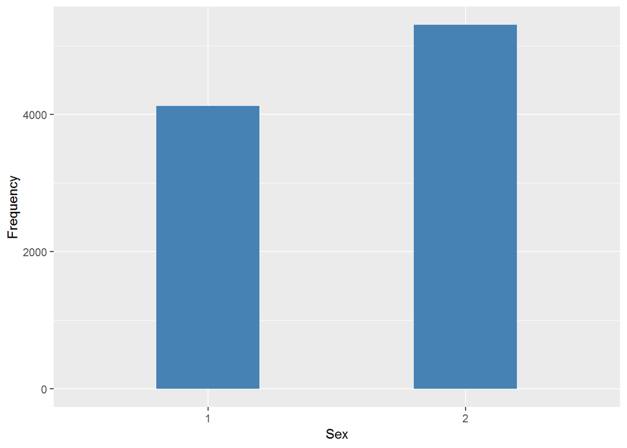

#### 2.1.2.2 Harmonisation algorithm

To compute the harmonized variable from the study-specific variable it has to be recoded as follows:

- `1 "Male" into 1`
- `2 "Female" into 0`
- `-9 "Refusal" into 997`
- `-8 "Don't Know" into 998`
- `-1 "Not applicable" into 996`
- `NA into 999`

**R script:**

```r
ELSA_ds_w2 <- tibble(id = ELSA_w2_sex$id)
ELSA_ds_w2$sex <- car::recode(ELSA_w2_sex$indsex, "1=1; 2=0;-9=997; -8=998")
ELSA_ds_w2$sex <- labelled(ELSA_ds_w2$sex, labels = c(Female = 0, Male = 1,
    Missing = 999, `Do not know` = 998, Refuse = 997, `Not attempt not done` = 994,
    `Does not answer` = 995, `Not applicable` = 996, `Disable to measure` = 993,
    Impute = 992, `CAPI interviewer error` = 991))
label(ELSA_ds_w2$sex) <- ds_label
```

#### 2.1.2.3 Statistical description of the new harmonised variable

Biological sex

| Sample size | Missing values |
| --- | --- |
| 9432 | 0 |

Category

|  | 0 | 1 |
| --- | --- | --- |
| Frequency | 5307.00 | 4125.00 |
| Percentage | 56.27 | 43.73 |

Type of missing

|  | 991 | 992 | 993 | 994 | 995 | 996 | 997 | 998 | 999 | NA |
| --- | --- | --- | --- | --- | --- | --- | --- | --- | --- | --- |
| Frequency | 0 | 0 | 0 | 0 | 0 | 0 | 0 | 0 | 0 | 0 |
| Percentage | 0 | 0 | 0 | 0 | 0 | 0 | 0 | 0 | 0 | 0 |

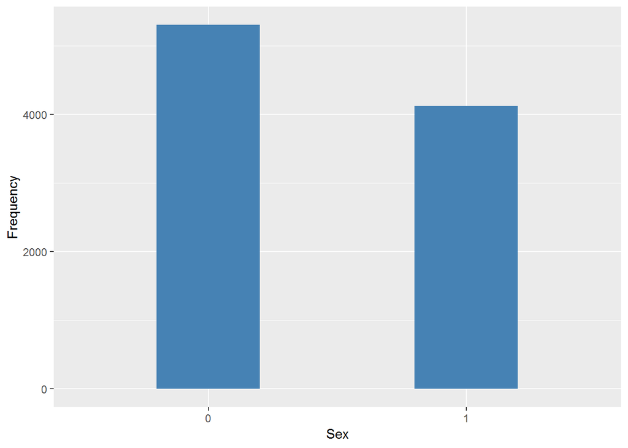

#### 2.1.2.4 Validation

|  | 2->0 | 1 |
| --- | --- | --- |
| BeforeH | 5307 | 4125 |
| AfterH | 5307 | 4125 |

### 2.1.3 Wave 3

#### 2.1.3.1 Study-specific variable description

| **Name** | `indsex` |
| --- | --- |
| **Label** | `Definitive sex variable. Priority: Disex, Dhsex` |
| **Table name** | `wave_3_elsa_data_v4` |
| **Categories** | `1 = Male` `2 = Female` |
| **Missings** | `-9 = Refusal` `-8 = Don't Know` `-1 = Not applicable` |
| **Description** |  |

Biological sex

| Sample size | Missing values |
| --- | --- |
| 9771 | 0 |

Category

|  | 1 | 2 |
| --- | --- | --- |
| Frequency | 4295.00 | 5476.00 |
| Percentage | 43.96 | 56.04 |

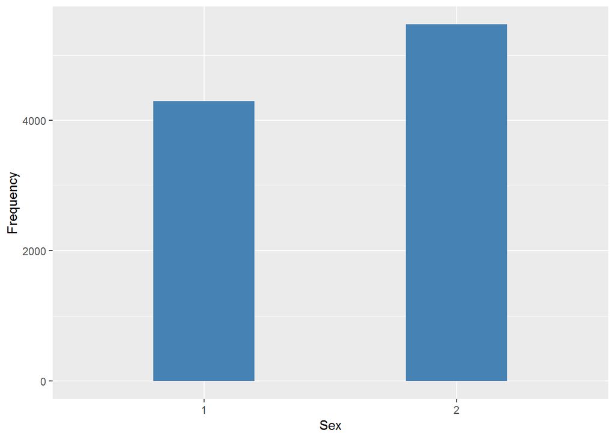

#### 2.1.3.2 Harmonisation algorithm

To compute the harmonized variable from the study-specific variable it has to be recoded as follows:

- `1 "Male" into 1`
- `2 "Female" into 0`
- `-9 "Refusal" into 997`
- `-8 "Don't Know" into 998`
- `-1 "Not applicable" into 996`
- `NA into 999`

**R script:**

```r
ELSA_ds_w3 <- tibble(id = ELSA_w3_sex$id)
ELSA_ds_w3$sex <- car::recode(ELSA_w3_sex$indsex, "1=1; 2=0;-9=997; -8=998")
ELSA_ds_w3$sex <- labelled(ELSA_ds_w3$sex, labels = c(Female = 0, Male = 1,
    Missing = 999, `Do not know` = 998, Refuse = 997, `Not attempt not done` = 994,
    `Does not answer` = 995, `Not applicable` = 996, `Disable to measure` = 993,
    Impute = 992, `CAPI interviewer error` = 991))
label(ELSA_ds_w3$sex) <- ds_label
```

#### 2.1.3.3 Statistical description of the new harmonised variable

Biological sex

| Sample size | Missing values |
| --- | --- |
| 9771 | 0 |

Category

|  | 0 | 1 |
| --- | --- | --- |
| Frequency | 5476.00 | 4295.00 |
| Percentage | 56.04 | 43.96 |

Type of missing

|  | 991 | 992 | 993 | 994 | 995 | 996 | 997 | 998 | 999 | NA |
| --- | --- | --- | --- | --- | --- | --- | --- | --- | --- | --- |
| Frequency | 0 | 0 | 0 | 0 | 0 | 0 | 0 | 0 | 0 | 0 |
| Percentage | 0 | 0 | 0 | 0 | 0 | 0 | 0 | 0 | 0 | 0 |

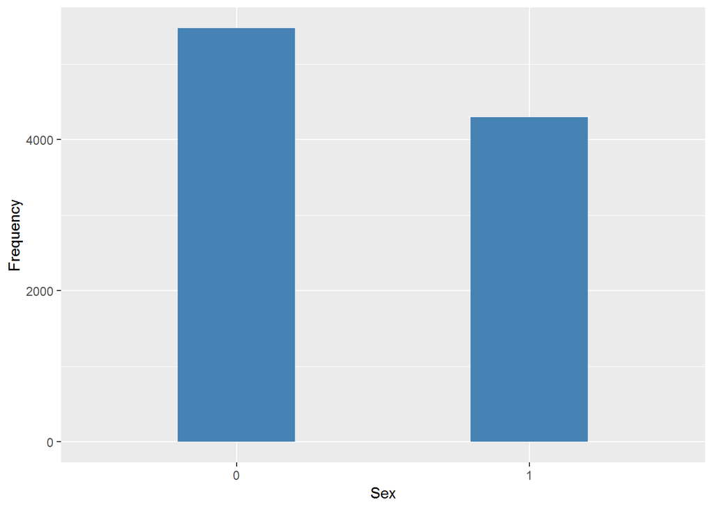

#### 2.1.3.4 Validation

|  | 2->0 | 1 |
| --- | --- | --- |
| BeforeH | 5476 | 4295 |
| AfterH | 5476 | 4295 |

### 2.1.4 Wave 4

#### 2.1.4.1 Study-specific variable description

| **Name** | `indsex` |
| --- | --- |
| **Label** | `Definitive sex variable. Priority: Disex, Dhsex` |
| **Table name** | `wave_4_elsa_data_v3` |
| **Categories** | `1 = Male` `2 = Female` |
| **Description** |  |

Biological sex

| Sample size | Missing values |
| --- | --- |
| 11050 | 0 |

Category

|  | 1 | 2 |
| --- | --- | --- |
| Frequency | 4925.00 | 6125.00 |
| Percentage | 44.57 | 55.43 |

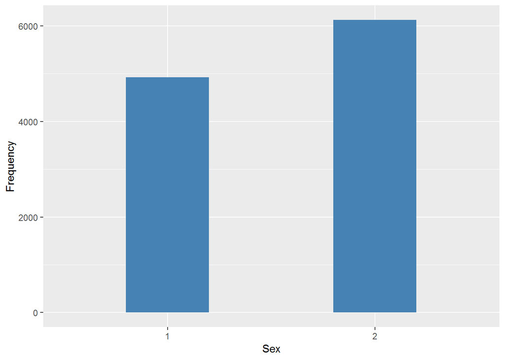

#### 2.1.4.2 Harmonisation algorithm

To compute the harmonized variable from the study-specific variable it has to be recoded as follows:

- `1 "Male" into 1`
- `2 "Female" into 0`
- `NA into 999`

**R script:**

```r
ELSA_ds_w4 <- tibble(id = ELSA_w4_sex$id)
ELSA_ds_w4$sex <- car::recode(ELSA_w4_sex$indsex, "1=1; 2=0;-9=997; -8=998")
ELSA_ds_w4$sex <- labelled(ELSA_ds_w4$sex, labels = c(Female = 0, Male = 1,
    Missing = 999, `Do not know` = 998, Refuse = 997, `Not attempt not done` = 994,
    `Does not answer` = 995, `Not applicable` = 996, `Disable to measure` = 993,
    Impute = 992, `CAPI interviewer error` = 991))
label(ELSA_ds_w4$sex) <- ds_label
```

#### 2.1.4.3 Statistical description of the new harmonised variable

Biological sex

| Sample size | Missing values |
| --- | --- |
| 11050 | 0 |

Category

|  | 0 | 1 |
| --- | --- | --- |
| Frequency | 6125.00 | 4925.00 |
| Percentage | 55.43 | 44.57 |

Type of missing

|  | 991 | 992 | 993 | 994 | 995 | 996 | 997 | 998 | 999 | NA |
| --- | --- | --- | --- | --- | --- | --- | --- | --- | --- | --- |
| Frequency | 0 | 0 | 0 | 0 | 0 | 0 | 0 | 0 | 0 | 0 |
| Percentage | 0 | 0 | 0 | 0 | 0 | 0 | 0 | 0 | 0 | 0 |

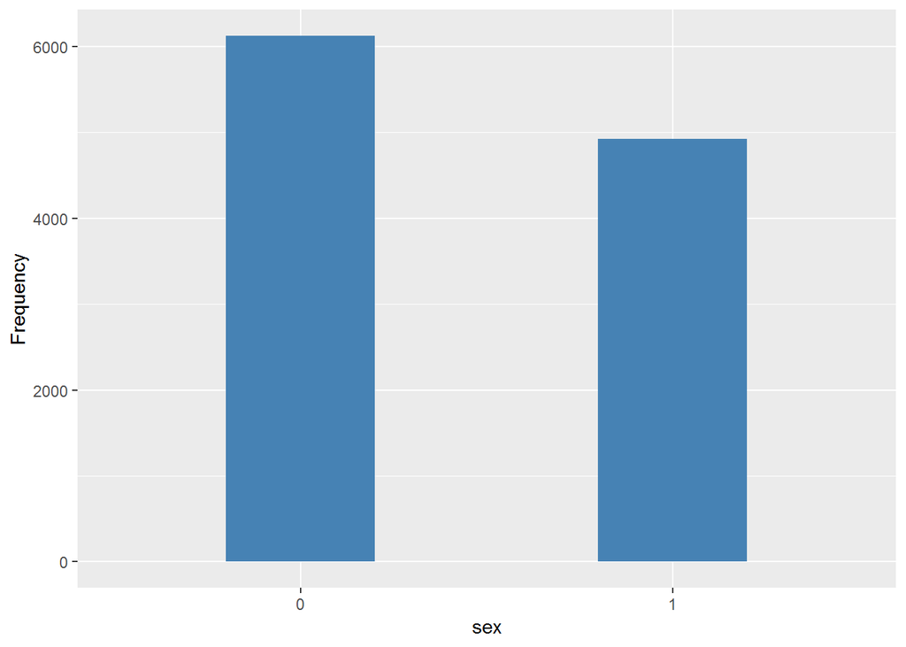

#### 2.1.4.4 Validation

|  | 2->0 | 1 |
| --- | --- | --- |
| BeforeH | 6125 | 4925 |
| AfterH | 6125 | 4925 |

### 2.1.5 Wave 5

#### 2.1.5.1 Study-specific variable description

| **Name** | `indsex` |
| --- | --- |
| **Label** | `Definitive sex variable. Priority: Disex, Dhsex` |
| **Table name** | `wave_5_elsa_data_v4` |
| **Categories** | `1 = Male` `2 = Female` |
| **Description** |  |

Biological sex

| Sample size | Missing values |
| --- | --- |
| 10274 | 0 |

Category

|  | 1 | 2 |
| --- | --- | --- |
| Frequency | 4569.00 | 5705.00 |
| Percentage | 44.47 | 55.53 |

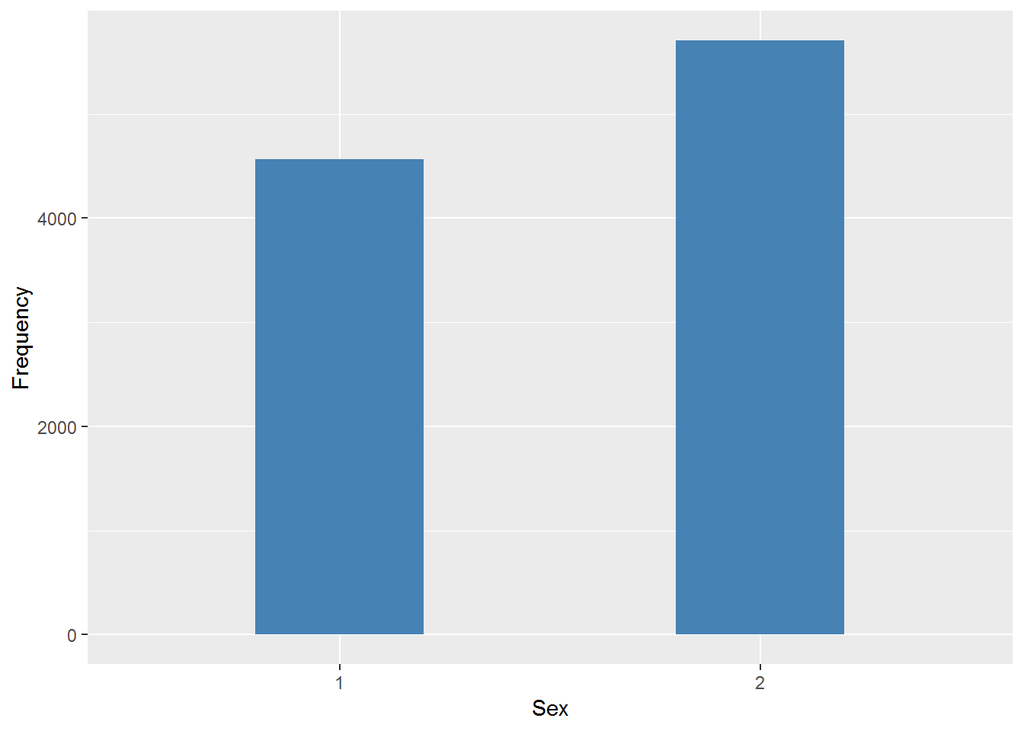

#### 2.1.5.2 Harmonisation algorithm

To compute the harmonized variable from the study-specific variable it has to be recoded as follows:

- `1 "Male" into 1`
- `2 "Female" into 0`
- `NA into 999`

**R script:**

```r
ELSA_ds_w5 <- tibble(id = ELSA_w5_sex$id)
ELSA_ds_w5$sex <- car::recode(ELSA_w5_sex$indsex, "1=1; 2=0;-9=997; -8=998")
ELSA_ds_w5$sex <- labelled(ELSA_ds_w5$sex, labels = c(Female = 0, Male = 1,
    Missing = 999, `Do not know` = 998, Refuse = 997, `Not attempt not done` = 994,
    `Does not answer` = 995, `Not applicable` = 996, `Disable to measure` = 993,
    Impute = 992, `CAPI interviewer error` = 991))
label(ELSA_ds_w5$sex) <- ds_label
```

#### 2.1.5.3 Statistical description of the new harmonised variable

Biological sex

| Sample size | Missing values |
| --- | --- |
| 10274 | 0 |

Category

|  | 0 | 1 |
| --- | --- | --- |
| Frequency | 5705.00 | 4569.00 |
| Percentage | 55.53 | 44.47 |

Type of missing

|  | 991 | 992 | 993 | 994 | 995 | 996 | 997 | 998 | 999 | NA |
| --- | --- | --- | --- | --- | --- | --- | --- | --- | --- | --- |
| Frequency | 0 | 0 | 0 | 0 | 0 | 0 | 0 | 0 | 0 | 0 |
| Percentage | 0 | 0 | 0 | 0 | 0 | 0 | 0 | 0 | 0 | 0 |

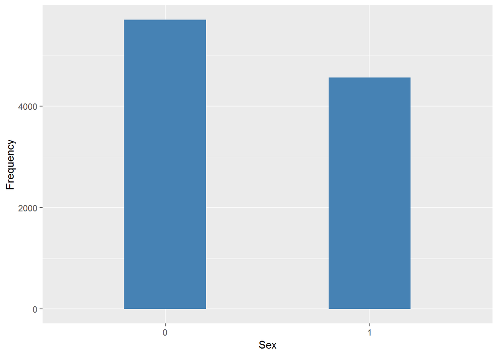

#### 2.1.5.4 Validation

|  | 2->0 | 1 |
| --- | --- | --- |
| BeforeH | 5705 | 4569 |
| AfterH | 5705 | 4569 |

### 2.1.6 Wave 6

#### 2.1.6.1 Study-specific variable description

| **Name** | `indsex` |
| --- | --- |
| **Label** | `Definitive sex variable. Priority: Disex, Dhsex` |
| **Table name** | `wave_6_elsa_data_v2` |
| **Categories** | `1 = Male` `2 = Female` |
| **Description** |  |

Biological sex

| Sample size | Missing values |
| --- | --- |
| 10601 | 0 |

Category

|  | 1 | 2 |
| --- | --- | --- |
| Frequency | 4744.00 | 5857.00 |
| Percentage | 44.75 | 55.25 |

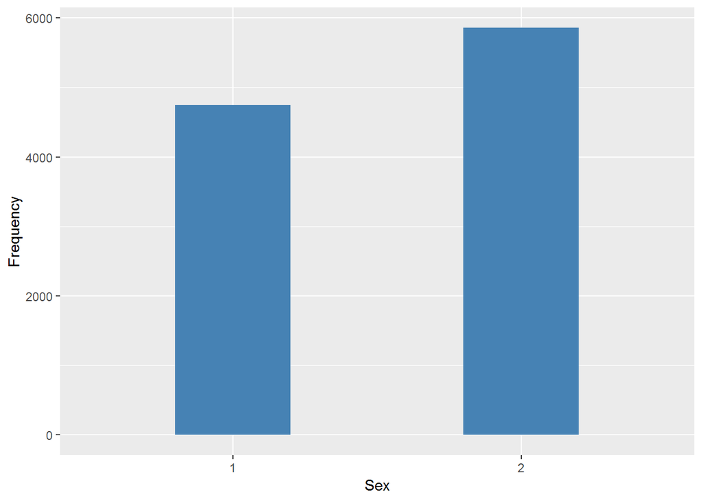

#### 2.1.6.2 Harmonisation algorithm

To compute the harmonized variable from the study-specific variable it has to be recoded as follows:

- `1 "Male" into 1`
- `2 "Female" into 0`
- `NA into 999`

**R script:**

```r
ELSA_ds_w6 <- tibble(id = ELSA_w6_sex$id)
ELSA_ds_w6$sex <- car::recode(ELSA_w6_sex$indsex, "1=1; 2=0;-9=997; -8=998")
ELSA_ds_w6$sex <- labelled(ELSA_ds_w6$sex, labels = c(Female = 0, Male = 1,
    Missing = 999, `Do not know` = 998, Refuse = 997, `Not attempt not done` = 994,
    `Does not answer` = 995, `Not applicable` = 996, `Disable to measure` = 993,
    Impute = 992, `CAPI interviewer error` = 991))
label(ELSA_ds_w6$sex) <- ds_label
```

#### 2.1.6.3 Statistical description of the new harmonised variable

Biological sex

| Sample size | Missing values |
| --- | --- |
| 10601 | 0 |

Category

|  | 0 | 1 |
| --- | --- | --- |
| Frequency | 5857.00 | 4744.00 |
| Percentage | 55.25 | 44.75 |

Type of missing

|  | 991 | 992 | 993 | 994 | 995 | 996 | 997 | 998 | 999 | NA |
| --- | --- | --- | --- | --- | --- | --- | --- | --- | --- | --- |
| Frequency | 0 | 0 | 0 | 0 | 0 | 0 | 0 | 0 | 0 | 0 |
| Percentage | 0 | 0 | 0 | 0 | 0 | 0 | 0 | 0 | 0 | 0 |

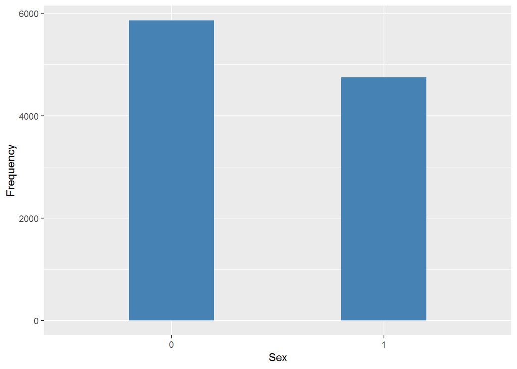

#### 2.1.6.4 Validation

|  | 2->0 | 1 |
| --- | --- | --- |
| BeforeH | 5857 | 4744 |
| AfterH | 5857 | 4744 |

### 2.1.7 Wave 7

#### 2.1.7.1 Study-specific variable description

| **Name** | `indsex` |
| --- | --- |
| **Label** | `Definitive sex variable: priority disex, dhsex` |
| **Table name** | `wave_7_elsa_data` |
| **Categories** | `1 = Male` `2 = Female` |
| **Description** |  |

indsex

| Sample size | Missing values |
| --- | --- |
| 9666 | 0 |

Category

|  | 1 | 2 |
| --- | --- | --- |
| Frequency | 4298.00 | 5368.00 |
| Percentage | 44.47 | 55.53 |

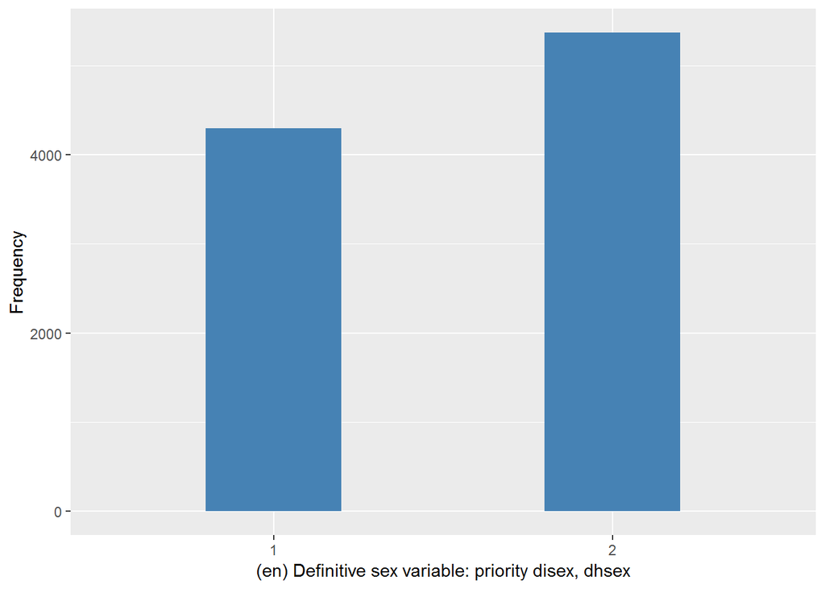

#### 2.1.7.2 Harmonisation algorithm

To compute the harmonized variable from the study-specific variable it has to be recoded as follows:

- `1 "Male" into 1`
- `2 "Female" into 0`

**R script:**

```r
ELSA_ds_w7 <- tibble(id = ELSA_w7$id)
ELSA_ds_w7$sex <- car::recode(ELSA_w7$indsex, "1=1; 2=0")
ELSA_ds_w7$sex <- labelled(ELSA_ds_w7$sex, labels = c(Female = 0, Male = 1,
    Missing = 999, `Do not know` = 998, Refuse = 997, `Not attempt not done` = 994,
    `Does not answer` = 995, `Not applicable` = 996, `Disable to measure` = 993,
    Impute = 992, `CAPI interviewer error` = 991))
label(ELSA_ds_w7$sex) <- ds_label
```

#### 2.1.7.3 Statistical description of the new harmonised variable

Biological sex

| Sample size | Missing values |
| --- | --- |
| 9666 | 0 |

Category

|  | 0 | 1 |
| --- | --- | --- |
| Frequency | 5368.00 | 4298.00 |
| Percentage | 55.53 | 44.47 |

Type of missing

|  | 991 | 992 | 993 | 994 | 995 | 996 | 997 | 998 | 999 | NA |
| --- | --- | --- | --- | --- | --- | --- | --- | --- | --- | --- |
| Frequency | 0 | 0 | 0 | 0 | 0 | 0 | 0 | 0 | 0 | 0 |
| Percentage | 0 | 0 | 0 | 0 | 0 | 0 | 0 | 0 | 0 | 0 |

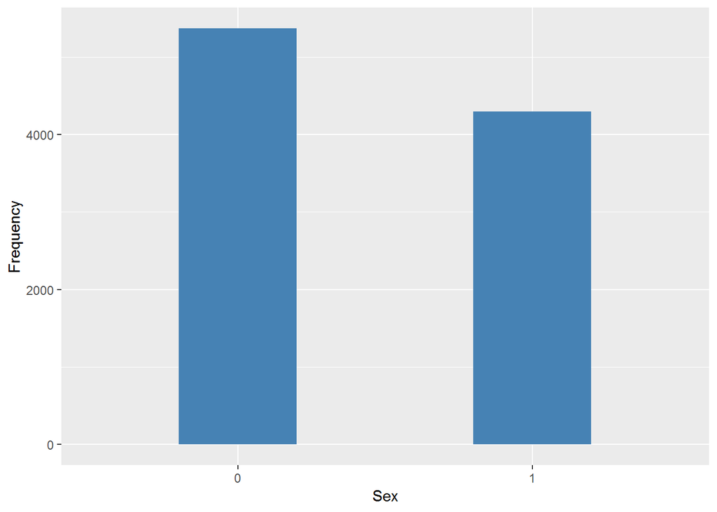

#### 2.1.7.4 Validation

|  | 2->0 | 1 |
| --- | --- | --- |
| BeforeH | 5368 | 4298 |
| AfterH | 5368 | 4298 |

## 2.2 Summary of descriptive statistics of the harmonised variable accross populations and waves

Two tables are generated:

1. Percentages of categories in each harmonised variable.
2. Frequencies and percentages of individuals with different trajectories. To avoid too large table, Only trajectories with percentages larger than 0.3 are shown.

Biological sex

| val | label | W1 | W2 | W3 | W4 | W5 | W6 | W7 |
| --- | --- | --- | --- | --- | --- | --- | --- | --- |
| 0 | Female | 55.91 | 56.27 | 56.04 | 55.43 | 55.53 | 55.25 | 55.53 |
| 1 | Male | 44.09 | 43.73 | 43.96 | 44.57 | 44.47 | 44.75 | 44.47 |
| 991 | CAPI interviewer error | 0 | 0 | 0 | 0 | 0 | 0 | 0 |
| 992 | Impute | 0 | 0 | 0 | 0 | 0 | 0 | 0 |
| 993 | Disable to measure | 0 | 0 | 0 | 0 | 0 | 0 | 0 |
| 994 | Not attempt not done | 0 | 0 | 0 | 0 | 0 | 0 | 0 |
| 995 | Does not answer | 0 | 0 | 0 | 0 | 0 | 0 | 0 |
| 996 | Not applicable | 0 | 0 | 0 | 0 | 0 | 0 | 0 |
| 997 | Refuse | 0 | 0 | 0 | 0 | 0 | 0 | 0 |
| 998 | Do not know | 0 | 0 | 0 | 0 | 0 | 0 | 0 |
| 999 | Missing | 0 | 0 | 0 | 0 | 0 | 0 | 0 |
| NA | NA | 0 | 0 | 0 | 0 | 0 | 0 | 0 |
| n | sample size | 12099 | 9432 | 9771 | 11050 | 10274 | 10601 | 9666 |

|  | val | frq | raw.prc |
| --- | --- | --- | --- |
| 1 | 0000000 | 2545 | 13.76 |
| 2 | 000000NA | 383 | 2.07 |
| 4 | 00000NANA | 276 | 1.49 |
| 8 | 0000NANANA | 331 | 1.79 |
| 9 | 000NA000 | 69 | 0.37 |
| 16 | 000NANANANA | 495 | 2.68 |
| 17 | 00NA0000 | 61 | 0.33 |
| 32 | 00NANANANANA | 699 | 3.78 |
| 33 | 0NA00000 | 59 | 0.32 |
| 46 | 0NA0NANANANA | 65 | 0.35 |
| 62 | 0NANANANANANA | 1112 | 6.01 |
| 64 | 1111111 | 1836 | 9.93 |
| 65 | 111111NA | 297 | 1.61 |
| 67 | 11111NANA | 224 | 1.21 |
| 71 | 1111NANANA | 286 | 1.55 |
| 79 | 111NANANANA | 442 | 2.39 |
| 80 | 11NA1111 | 56 | 0.30 |
| 95 | 11NANANANANA | 591 | 3.20 |
| 123 | 1NANANANANANA | 970 | 5.25 |
| 154 | NANA00000 | 464 | 2.51 |
| 155 | NANA0000NA | 57 | 0.31 |
| 161 | NANA00NANANA | 67 | 0.36 |
| 168 | NANA0NANANANA | 159 | 0.86 |
| 169 | NANA11111 | 403 | 2.18 |
| 170 | NANA1111NA | 62 | 0.34 |
| 177 | NANA11NANANA | 56 | 0.30 |
| 185 | NANA1NANANANA | 146 | 0.79 |
| 186 | NANANA0000 | 895 | 4.84 |
| 187 | NANANA000NA | 140 | 0.76 |
| 189 | NANANA00NANA | 94 | 0.51 |
| 193 | NANANA0NANANA | 173 | 0.94 |
| 194 | NANANA1111 | 814 | 4.40 |
| 195 | NANANA111NA | 128 | 0.69 |
| 197 | NANANA11NANA | 90 | 0.49 |
| 201 | NANANA1NANANA | 192 | 1.04 |
| 209 | NANANANANA00 | 516 | 2.79 |
| 210 | NANANANANA0NA | 127 | 0.69 |
| 212 | NANANANANA11 | 433 | 2.34 |
| 213 | NANANANANA1NA | 138 | 0.75 |
| 214 | NANANANANANA0 | 259 | 1.40 |
| 215 | NANANANANANA1 | 250 | 1.35 |

# 3 Quality estimation

There are 3 individuals with sex data changing across waves.

| val | frq | label | raw.prc | valid.prc | cum.prc |
| --- | --- | --- | --- | --- | --- |
| FALSE | 3 |  | 0.02 | 0.02 | 2e-02 |
| TRUE | 14903 |  | 80.60 | 99.98 | 1e+02 |
| NA | 3583 |  | 19.38 | NA | NA |

| id | sex.w1 | sex.w2 | sex.w3 | sex.w4 | sex.w5 | sex.w6 | sex | var |
| --- | --- | --- | --- | --- | --- | --- | --- | --- |
| 112435 | 1 | 0 | 1 | 1 | 1 | 1 | NA | 0.1666667 |
| 121378 | NA | NA | 1 | 1 | 1 | NA | 0 | 0.2500000 |
| 165195 | NA | NA | NA | NA | NA | 1 | 0 | 0.5000000 |

We do not anything thereon.